# Sistem Agribisnis dan Manajemen Agribisnis

Tedy Herlambang

2023-03-16

[figure not shown]

### Capaian Pembelajaran

Setelah mempelajari bab ini, mahasiswa seharusnya dapat:

- Mendefinisikan dan menjelaskan agribisnis sebagai sebuah sistem dan manajemen
- Menjelaskan asal muasal agribisnis dan perkembangannya
- Menjelaskan perbedaan antara agribisnis dengan bisnis tradisional
- Mengidentifikasi komponen utama agribisnis di jaman sekarang
- Menjelaskan pentingnya model manajemen agribisnis
- Menjelaskan pertumbuhan peluang di dalam agribisnis

### Definisi Agribisnis

- Agribisnis meliputi kegiatan produksi, distribusi, dan konsumsi pangan, pakaian dan perumahan.
- Agribisnis meliputi seluruh aktivitas ekonomi di dalam sistem pangan dan serat:
  - Industri saprotan: benih, pupuk, alsintan dll,
  - Produksi pertanian,
  - Pasca panen dan kegiatan yang menciptakan nilai tambah: pengepakan, pengolahan, pengawetan, dan distribusi.
- Sebagian besar orang mengerti dan melihat bagian-bagiannya, tetapi hanya beberapa yang melihatnya secara utuh.
- Pada tahun 1957 konsep Agribisnis pertama kali diperkenalkan

### Agribisnis Sekarang

- Peusahaan Agribisnis meliputi industri pengolahan sampai pemasok input pertanian.
- Membutuhkan karyawan yang handal: softskill dan hardskill.

### Industri-Industri Inti di dalam Agribisnis

- Hampir semua orang tahu apa itu “bisnis” –> Bagaimana dengan Agribisnis?
- Agribisnis meliputi:
  1. Produsen benih/bibit, pupuk, obat-obatan, pembiayaan, peralatan yang digunakan dalam produksi pertanian;
  2. Kegiatan pasca panen dan pengolahan: grading, penyimpanan, pengolahan, pengepakan, distribusi, penetapan harga dan pemasaran;
  3. Konsumsi akhir: restoran, supermarket, pasar traditional.

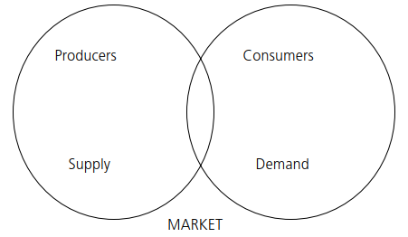

- Jadi industri inti agribisnis ada tiga: *input supply industries, production agriculture* dan *value-added activities*.
- Farming are part of the core of agribusiness. But, they are not the end; they are not even the beginning.

### Model Manajemen Agribisnis

- Selama berabad-abad, produktivitas pertanian berasal dari dua sumberdaya: tanah dan tenaga kerja.
- Akhir-akhir ini ada faktor lain: **kapital** khususnya dalam bentuk kemajuan teknologi seperti biotechnology, improved animal husbandry, and improvements in machinery and chemicals.
- Ke depan selain faktor tanah, tenaga dan teknologi, satu fakto lagi: **manajemen**.
- Agribisnis memerlukan manajer yang mampu menggunakan sumberdaya untuk “memindahkan” produk yang gampang rusak dan busuk (*a perishable product*) ke pasar sasaran –> Manajemen Agribisnis

### Rantai Agribisnis – Rantai Nilai

- Keterkaitan antar kegiatan agribisnis –> rantai agribisnis.
- Disebut juga rantai nilai agribisnis (agribusiness value chain).
- Dimulai dari bahan mentah/baku atau komoditas dengan nilai rendah.
- Setiap tahap di dalam rantai memodif materi dan menambah nilai pada produk.

### Contoh Rantai Pasok Buah

- Petani memanen mangga, diangkut oleh pedagang pengumpul, pedagang besar, konsumen…adakah jalur lain?
- Nilai apa yang diciptakan oleh masing-masing pelaku di rantai nilai agribisnis?
  - Pedagang pengumpul?
  - Penebas?
  - Pedagang besar?
  - Supermarket?
  - dan lain-lain

### Pandangan berbeda tentang agribisnis

- Agribusiness involves all the value chain activities usually associated with a business or industry with the additional provision that most of the materials, commodities, and end products are **perishable** (ringkih, gampang rusak, cepat busuk).
- The perishable nature of a product, along with variability in such factors as color, texture, size, and shape, is the distinguishing characteristic of agribusiness products and industries from other businesses.

> This aspect of the agribusiness industry is also a key factor in all business decisions.

### Agribisnis di sekitar kita

- Ayam Geprek, Bebek Goreng Kios Buah adalah cerita agribisnis
- Perusahaan besar multinational
- Bagaimana dengan Warteg, Warung Padang, Warung Nasi Pecel dan Rawon?
- Semuanya melibatkan komoditas yang mudah rusak dan busuk: daging ayam, beras, bumbu-bumbu, minyak goreng, dll.

### Diskusi

- Berikan contoh perusahaan, usaha, kegiatan yang bisa dikategorikan sebagai agribisnis disekitar Anda!
- Bagaimana dengan peluang usaha di bidang Agribisnis di sekitar Anda?